# OPENCLASSROOMS - PROJET 3

# ÉTUDE DE SANTÉ PUBLIQUE

## Sommaire

###### Un code de couleur à été attribué aux différentes parties à titre de repère

## I. Population mondiale et disponibilité alimentaire en 2013

**Question 1:** *Donnez le résultat de votre calcul pour l'année 2013.*

**Question 2:** _Identifiez ces redondances, en donnant votre réponse sous forme de formule mathématique (pas besoin de coder ici). C'est une équation à 3 termes de type (a_1 + a2 + [...] = b_1 + b_2 + [...] = c_1 + c*2 + [...]) ) faisant intervenir chacune des 11 quantités données ci dessus. Illustrez cette équation avec l'exemple du blé en France.*

**Question 3:** *Calculez (pour chaque pays et chaque produit) la disponibilité alimentaire en kcal puis en kg de protéines.*

**Question 4:** *À partir de ces dernières informations, et à partir du poids de la disponibilité alimentaire (pour chaque pays et chaque produit), calculez pour chaque produit le ratio "énergie/poids", que vous donnerez en kcal/kg. Vous pouvez vérifier la cohérence de votre calcul en comparant ce ratio aux données disponibles sur internet, par exemple en cherchant la valeur calorique d'un oeuf.*

**Question 5:** *Citez 5 aliments parmi les 20 aliments les plus caloriques, en utilisant le ratio énergie/poids. Étonnamment, il arrive que ce ratio soit différent en fonction du pays. Il faudra donc réaliser pour chaque aliment une moyenne sur les différents pays. Vous créerez donc une nouvelle table grâce à une agrégation. Attention à bien retirer les valeurs égales à 0 afin de ne pas fausser le calcul de la moyenne. Citez 5 aliments parmi les 20 aliments les plus riches en protéines.*

## II. Disponibilité intérieure mondiale en produits végétaux

**Question 6:** *Calculez, pour les produits végétaux uniquement, la disponibilité intérieure mondiale exprimée en kcal.*

**Question 7:** *Combien d'humains pourraient être nourris si toute la disponibilité intérieure mondiale de produits végétaux était utilisée pour de la nourriture? Donnez les résultats en termes de calories, puis de protéines, et exprimez ensuite ces 2 résultats en pourcentage de la population mondiale.*

**Question 8:** *Combien d'humains pourraient être nourris si toute la disponibilité alimentaire en produits végétaux la nourriture végétale destinée aux animaux et les pertes de produits végétaux étaient utilisés pour de la nourriture ? Donnez les résultats en termes de calories, puis de protéines, et exprimez ensuite ces 2 résultats en pourcentage de la population mondiale.*

**Question 9:** *Combien d'humains pourraient être nourris avec la disponibilité alimentaire mondiale? Donnez les résultats en termes de calories, puis de protéines, et exprimez ensuite ces 2 résultats en pourcentage de la population mondiale.*

## III. Pays en sous-nutrition, importations et exportations

**Question 10:** *À partir des données téléchargées qui concernent la sous-nutrition, répondez à cette question : Quelle proportion de la population mondiale est considérée comme étant en sous-nutrition?*

**Question 11:** *En ne prenant en compte que les céréales destinées à l'alimentation (humaine et animale), quelle proportion (en termes de poids) est destinée à l'alimentation animale?*

**Question 12:** *Sélectionnez parmi les données des bilans alimentaires les informations relatives aux pays dans lesquels la FAO recense des personnes en sous-nutrition. Repérez les 15 produits les plus exportés par ce groupe de pays. Parmi les données des bilans alimentaires au niveau mondial, sélectionnez les 200 plus grandes importations de ces produits (1 importation = une quantité d'un produit donné importée par un pays donné). Groupez ces importations par produit, afin d'avoir une table contenant 1 ligne pour chacun des 15 produits. Ensuite, calculez pour chaque produit les 2 quantités suivantes: le ratio entre la quantité destinés aux "Autres utilisations" (Other uses) et la disponibilité intérieure et le ratio entre la quantité destinée à la nourriture animale et la quantité destinée à la nourriture (animale + humaine). Donnez les 3 produits qui ont la plus grande valeur pour chacun des 2 ratios (vous aurez donc 6 produits à citer).*

**Question 13:** *Combien de tonnes de céréales pourraient être libérées si les USA diminuaient leur production de produits animaux de 10%?*

**Question 14:** *En Thaïlande, quelle proportion de manioc est exportée ? Quelle est la proportion de personnes en sous-nutrition?*

```python
import numpy as np
import pandas as pd

import matplotlib.pyplot as plt
from matplotlib.pyplot import figure
```

# I. Population mondiale et disponibilité alimentaire en 2013

### **Question 1:** *Donnez le résultat de votre calcul pour l'année 2013.*

Nous appelons ici le DataFrame "pop3" qui contient le nombre d'habitants de chaque pays en 2013, arrondi à 1000.

```python
pop3 = pd.read_csv("data/projet_3/clean/population_clean.csv")
POPULATION_2013 = sum(pop3.population)
print("On compte %s êtres humains sur Terre en 2013." %POPULATION_2013) ; pop3
```

```
On compte 6997326000 êtres humains sur Terre en 2013.
```

|  | country_code | country | year | population |
| --- | --- | --- | --- | --- |
| 0 | 2 | Afghanistan | 2013 | 30552000 |
| 1 | 202 | Afrique du Sud | 2013 | 52776000 |
| 2 | 3 | Albanie | 2013 | 3173000 |
| 3 | 4 | Algérie | 2013 | 39208000 |
| 4 | 79 | Allemagne | 2013 | 82727000 |
| ... | ... | ... | ... | ... |
| 169 | 236 | Venezuela (République bolivarienne du) | 2013 | 30405000 |
| 170 | 237 | Viet Nam | 2013 | 91680000 |
| 171 | 249 | Yémen | 2013 | 24407000 |
| 172 | 251 | Zambie | 2013 | 14539000 |
| 173 | 181 | Zimbabwe | 2013 | 14150000 |

174 rows × 4 columns

### **Question 2:** _Identifiez ces redondances, en donnant votre réponse sous forme de formule mathématique (pas besoin de coder ici). C'est une équation à 3 termes de type (a_1 + a2 + [...] = b_1 + b_2 + [...] = c_1 + c*2 + [...]) ) faisant intervenir chacune des 11 quantités données ci dessus. Illustrez cette équation avec l'exemple du blé en France.*

Ici, nous présentons "ba13", le bilan alimentaire à jour pour l'année 2013, que nous utiliserons dans la suite du sujet.

```python
ba13 = pd.read_csv("data/projet_3/clean/bilan_alimentaire.csv") ; ba13
```

|  | country_code | country | item_code | item | year | origin | feed | other_uses | food_supply_kcalcapitaday | domestic_supply_quantity_kgcapitayear | ... | protein_domestic_supply_gcapitaday | domestic_supply | exportation_quantity | importation_quantity | food | waste | production | seed | processing | stock_variation |
| --- | --- | --- | --- | --- | --- | --- | --- | --- | --- | --- | --- | --- | --- | --- | --- | --- | --- | --- | --- | --- | --- |
| 0 | 1 | Arménie | 2511 | Blé | 2013 | vegetal | 93.0 | 0.0 | 1024.0 | 130.60 | ... | 30.52 | 554.0 | 1.0 | 361.0 | 389.0 | 32.0 | 312.0 | 30.0 | 10.0 | -118.0 |
| 1 | 1 | Arménie | 2513 | Orge | 2013 | vegetal | 137.0 | 26.0 | 0.0 | 0.00 | ... | 0.00 | 198.0 | 0.0 | 9.0 | 0.0 | 15.0 | 189.0 | 14.0 | 7.0 | 0.0 |
| 2 | 1 | Arménie | 2514 | Maïs | 2013 | vegetal | 96.0 | NaN | 0.0 | 0.03 | ... | 0.01 | 102.0 | NaN | 82.0 | 0.0 | 7.0 | 21.0 | 0.0 | NaN | NaN |
| 3 | 1 | Arménie | 2515 | Seigle | 2013 | vegetal | 1.0 | NaN | 1.0 | 0.12 | ... | 0.02 | 1.0 | NaN | 0.0 | 0.0 | 0.0 | 1.0 | 0.0 | NaN | 0.0 |
| 4 | 1 | Arménie | 2516 | Avoine | 2013 | vegetal | 4.0 | NaN | 2.0 | 0.37 | ... | 0.09 | 6.0 | NaN | 1.0 | 1.0 | 0.0 | 5.0 | 0.0 | NaN | NaN |
| ... | ... | ... | ... | ... | ... | ... | ... | ... | ... | ... | ... | ... | ... | ... | ... | ... | ... | ... | ... | ... | ... |
| 15697 | 351 | Chine | 2781 | Huiles de Poissons | 2013 | animal | 47.0 | 80.0 | 0.0 | 0.00 | ... | 0.00 | 127.0 | 13.0 | 91.0 | 0.0 | NaN | 50.0 | NaN | NaN | 0.0 |
| 15698 | 351 | Chine | 2782 | Huiles de Foie de Poisso | 2013 | animal | 0.0 | 0.0 | 0.0 | 0.00 | ... | 0.00 | 0.0 | 1.0 | 1.0 | 0.0 | NaN | 0.0 | NaN | NaN | 0.0 |
| 15699 | 351 | Chine | 2805 | Riz (Eq Blanchi) | 2013 | vegetal | 12117.0 | 2085.0 | 797.0 | 77.45 | ... | 14.47 | 135024.0 | 565.0 | 2714.0 | 109725.0 | 6406.0 | 136873.0 | 4679.0 | 12.0 | -3998.0 |
| 15700 | 351 | Chine | 2848 | Lait - Excl Beurre | 2013 | animal | 1632.0 | 42.0 | 59.0 | 33.18 | ... | 3.12 | 50117.0 | 233.0 | 9780.0 | 47009.0 | 1433.0 | 40570.0 | NaN | 0.0 | 0.0 |
| 15701 | 351 | Chine | 2899 | Miscellanees | 2013 | vegetal | NaN | NaN | 0.0 | NaN | ... | 0.01 | NaN | NaN | NaN | NaN | NaN | NaN | NaN | NaN | NaN |

15702 rows × 21 columns

Étudions ces données avec l'exemple du blé en France.

```python
frb = ba13[(ba13["country"] == "France") & (ba13["item"]== "Blé")]

A = (frb.production + frb.importation_quantity - frb.exportation_quantity + frb.stock_variation).values[0]
B = (frb.domestic_supply).values[0]
C = (frb.seed + frb.waste + frb.food +  frb.feed + frb.processing + frb.other_uses).values[0]

pd.DataFrame({"Production + Importation - Exportation + Variation de stock": [A],
              "Disponibilité intérieure": [B],
              "Semences + Pertes + Disponibilité Alimentaire + Nourriture Animale + Traitement + Autre": [C]},
              index=["Blé en France"])
```

|  | Production + Importation - Exportation + Variation de stock | Disponibilité intérieure | Semences + Pertes + Disponibilité Alimentaire + Nourriture Animale + Traitement + Autre |
| --- | --- | --- | --- |
| Blé en France | 20298.0 | 20298.0 | 20298.0 |

### **Question 3:** *Calculez (pour chaque pays et chaque produit) la disponibilité alimentaire en kcal puis en kg de protéines.*

Ajoutons la colonne population, représentant le nombre d'habitants d'un pays donné, à notre bilan alimentaire et déterminons, pour chaque pays et chaque produit, la disponibilité alimentaire en kcalories puis en kg de protéines.

```python
ba13 = pd.merge(ba13, pop3)

ba13["food_supply_kcal"] = ba13.food_supply_kcalcapitaday*365*ba13.population
ba13["food_supply_kgproteine"] = ba13.protein_domestic_supply_gcapitaday*365*ba13.population/1000

ba13[["food_supply_kcal", "food_supply_kgproteine"]]
```

|  | food_supply_kcal | food_supply_kgproteine |
| --- | --- | --- |
| 0 | 1.112684e+12 | 3.316318e+07 |
| 1 | 0.000000e+00 | 0.000000e+00 |
| 2 | 0.000000e+00 | 1.086605e+04 |
| 3 | 1.086605e+09 | 2.173210e+04 |
| 4 | 2.173210e+09 | 9.779445e+04 |
| ... | ... | ... |
| 15600 | 0.000000e+00 | 0.000000e+00 |
| 15601 | 0.000000e+00 | 5.542744e+05 |
| 15602 | 1.939960e+11 | 3.879921e+06 |
| 15603 | 4.364911e+12 | 2.182455e+08 |
| 15604 | 9.699802e+10 | 2.036958e+07 |

15605 rows × 2 columns

### **Question 4:** *À partir de ces dernières informations, et à partir du poids de la disponibilité alimentaire (pour chaque pays et chaque produit), calculez pour chaque produit le ratio "énergie/poids", que vous donnerez en kcal/kg. Vous pouvez vérifier la cohérence de votre calcul en comparant ce ratio aux données disponibles sur internet, par exemple en cherchant la valeur calorique d'un oeuf.*

Ici, nous déterminons le ratio énergie/poids en kcalories/kg et au pourcentage de protéine contenu dans chaque produit par pays, respectivement dans les nouvelles colonnes "food_supply_kcalakg" et "proteine_percentage".

```python
ba13.loc[ba13["food"]>0, "food_supply_kcalakg"] = ba13.food_supply_kcal/(1000000*ba13.food)
ba13.loc[ba13["food_supply_kgproteine"]>0,
         "proteine_percentage"]=100*ba13.food_supply_kcalakg*ba13.food_supply_kgproteine/ba13.food_supply_kcal

ba13[["food", "food_supply_kcalakg", "food_supply_kgproteine", "proteine_percentage"]]
```

|  | food | food_supply_kcalakg | food_supply_kgproteine | proteine_percentage |
| --- | --- | --- | --- | --- |
| 0 | 389.0 | 2860.368946 | 3.316318e+07 | 8.525240 |
| 1 | 0.0 | NaN | 0.000000e+00 | NaN |
| 2 | 0.0 | NaN | 1.086605e+04 | NaN |
| 3 | 0.0 | NaN | 2.173210e+04 | NaN |
| 4 | 1.0 | 2173.210000 | 9.779445e+04 | 9.779445 |
| ... | ... | ... | ... | ... |
| 15600 | 0.0 | NaN | 0.000000e+00 | NaN |
| 15601 | 5.0 | 0.000000 | 5.542744e+05 | NaN |
| 15602 | 48.0 | 4041.584167 | 3.879921e+06 | 8.083168 |
| 15603 | 5892.0 | 740.819908 | 2.182455e+08 | 3.704100 |
| 15604 | NaN | NaN | 2.036958e+07 | NaN |

15605 rows × 4 columns

D'après le site https://oeuf.ca/faq/valeur-nutritive-dun-oeuf/, la valeur calorique d'un oeuf est d'environ 1341 kcal/kg et d'après wikipédia https://fr.wikipedia.org/wiki/%C5%92uf_(aliment), la teneur en protéine de l'avoine est d'environ 10,7%. Vérifions la valeur calorique moyenne d'un oeuf et la teneur en protéine moyenne de l'avoine selon nos données.

```python
print("Valeur calorique d'un oeuf:",
      round(ba13.loc[(ba13["food_supply_kcalakg"]>0) & (ba13["item"]=="Oeufs")].food_supply_kcalakg.mean()), "kcal/kg")

print("Teneur en protéine de l'avoine:",
      round(ba13.loc[(ba13["proteine_percentage"]>0) & (ba13["item"]=="Avoine")].proteine_percentage.mean(), 2), "%")
```

```
Valeur calorique d'un oeuf: 1345 kcal/kg
Teneur en protéine de l'avoine: 8.41 %
```

### **Question 5:** *Citez 5 aliments parmi les 20 aliments les plus caloriques, en utilisant le ratio énergie/poids. Étonnamment, il arrive que ce ratio soit différent en fonction du pays. Il faudra donc réaliser pour chaque aliment une moyenne sur les différents pays. Vous créerez donc une nouvelle table grâce à une agrégation. Attention à bien retirer les valeurs égales à 0 afin de ne pas fausser le calcul de la moyenne. Citez 5 aliments parmi les 20 aliments les plus riches en protéines.*

Créons d'abord un filtre afin que les valeurs nulles ou NaN ne soient pas prise en compte dans le calcul de la moyenne du ratio énergie/poids pour chaque produit, ainsi qu'un filtre analogue pour la teneur en protéines puis créons une nouvelle table donnant la moyenne du ratio énergie/poids de chaque aliment sur les différents pays puis trions ce tableau par ordre décroissant selon la colonne food_supply_kcalakg et affichons-en les 5 premières lignes qui nous renvoient les 5 aliments les plus caloriques selon le ratio énergie/poids.

```python
filtre_kcalakg = ba13["food_supply_kcalakg"]>0
filtre_proteine = ba13["proteine_percentage"]>0

pd.DataFrame(ba13.loc[filtre_kcalakg].groupby("item").
             mean()["food_supply_kcalakg"].reset_index()).sort_values(by= "food_supply_kcalakg", ascending = False).head(5)
```

|  | item | food_supply_kcalakg |
| --- | --- | --- |
| 43 | Huiles de Foie de Poisso | 9982.932500 |
| 41 | Huile de Sésame | 9433.744729 |
| 40 | Huile de Son de Riz | 9361.549883 |
| 44 | Huiles de Poissons | 9003.715504 |
| 32 | Huile d'Arachide | 8935.765811 |

Puis créons une nouvelle table donnant la moyenne du pourcentage en protéines de chaque aliment sur les différents pays, trions ce tableau par ordre décroissant selon la colonne "protéine_percentage" et affichons-en les 5 premières lignes nous affichant donc les 5 aliments les plus riches en protéines.

```python
pd.DataFrame(ba13.loc[filtre_proteine].groupby("item").
             mean()["proteine_percentage"].reset_index()).sort_values(by= "proteine_percentage", ascending=False ).head(5)
```

|  | item | proteine_percentage |
| --- | --- | --- |
| 73 | Soja | 32.927514 |
| 26 | Graines Colza/Moutarde | 28.536511 |
| 5 | Arachides Decortiquees | 25.169062 |
| 62 | Pois | 22.290438 |
| 44 | Légumineuses Autres | 21.811912 |

# Introduction des données de 2012 à 2017

#### Jusqu'ici, nous n'avons traité le bilan alimentaire que pour l'année 2013. À partir de maintenant, nous traiterons le bilan alimentaire pour chaque année comprise entre 2012 et 2017.

Nous présenterons cependant les résultats de chaque question uniquement pour l'année 2013 (année choisie) ainsi que pour l'année 2017 (dernière année disponible sur la FAO). Nous allons donc commencer par présenter un bilan alimentaire réunissant les informations pour chacune de ces 6 années (2012 à 2017 inclus), où les données de 2012, 2014, 2015, 2016 et 2017 tirées des questions 1 à 5 auront été traitées au préalable.

```python
# Nous introduisons, dans un premier temps, les bilans alimentaires de chaque année comprise entre 2012 et 2017, dont les
# données ont été traitées de façon analogue au bilan alimentaire de 2013 pour les questions 1 à 5:
ba12 = pd.read_csv("data/projet_3/lustre/bapo/bap2012.csv")
ba14 = pd.read_csv("data/projet_3/lustre/bapo/bap2014.csv")
ba15 = pd.read_csv("data/projet_3/lustre/bapo/bap2015.csv")
ba16 = pd.read_csv("data/projet_3/lustre/bapo/bap2016.csv")
ba17 = pd.read_csv("data/projet_3/final/ba_var_2017.csv")

# Puis nous introduisons enfin LE bilan alimentaire pour les années 2013 ET 2017 que nous appellerons simplement ba:
ba = ba12.append(ba13.append(ba14.append(ba15.append(ba16.append(ba17))))).sort_values(by= ["country", "year"]) ; ba
```

|  | country_code | country | item_code | item | year | origin | feed | other_uses | food_supply_kcalcapitaday | domestic_supply_quantity_kgcapitayear | ... | waste | production | seed | processing | stock_variation | population | food_supply_kcal | food_supply_kgproteine | food_supply_kcalakg | proteine_percentage |
| --- | --- | --- | --- | --- | --- | --- | --- | --- | --- | --- | --- | --- | --- | --- | --- | --- | --- | --- | --- | --- | --- |
| 90 | 2 | Afghanistan | 2511 | Blé | 2012 | vegetal | NaN | NaN | 1378.0 | 161.27 | ... | 758.0 | 5050.0 | 316.0 | NaN | -500.0 | 29825000.0 | 1.500108e+13 | 4.045284e+08 | 3118.727703 | 8.410154 |
| 91 | 2 | Afghanistan | 2513 | Orge | 2012 | vegetal | 367.0 | NaN | 23.0 | 2.61 | ... | 52.0 | 504.0 | 22.0 | NaN | 0.0 | 29825000.0 | 2.503809e+11 | 7.729149e+06 | 3210.011218 | 9.909165 |
| 92 | 2 | Afghanistan | 2514 | Maïs | 2012 | vegetal | 200.0 | NaN | 22.0 | 2.60 | ... | 31.0 | 310.0 | 5.0 | NaN | NaN | 29825000.0 | 2.394948e+11 | 6.313952e+06 | 3110.321429 | 8.199938 |
| 93 | 2 | Afghanistan | 2517 | Millet | 2012 | vegetal | NaN | NaN | 4.0 | 0.47 | ... | 1.0 | 15.0 | 0.0 | NaN | NaN | 29825000.0 | 4.354450e+10 | 9.797512e+05 | 3110.321429 | 6.998223 |
| 94 | 2 | Afghanistan | 2520 | Céréales, Autres | 2012 | vegetal | NaN | NaN | 0.0 | 0.00 | ... | NaN | NaN | NaN | NaN | NaN | 29825000.0 | 0.000000e+00 | 0.000000e+00 | NaN | NaN |
| ... | ... | ... | ... | ... | ... | ... | ... | ... | ... | ... | ... | ... | ... | ... | ... | ... | ... | ... | ... | ... | ... |
| 1576 | 25 | Îles Salomon | 2781 | Huiles de Poissons | 2017 | animal | NaN | 0.0 | 0.0 | 0.00 | ... | NaN | NaN | NaN | NaN | NaN | 636040.0 | 0.000000e+00 | 0.000000e+00 | NaN | NaN |
| 1577 | 25 | Îles Salomon | 2782 | Huiles de Foie de Poisso | 2017 | animal | NaN | 0.0 | 0.0 | 0.00 | ... | NaN | NaN | NaN | NaN | NaN | 636040.0 | 0.000000e+00 | 0.000000e+00 | NaN | NaN |
| 1578 | 25 | Îles Salomon | 2805 | Riz (Eq Blanchi) | 2017 | vegetal | 8.0 | 0.0 | 606.0 | 92.78 | ... | 0.0 | 3.0 | 0.0 | NaN | -11.0 | 636040.0 | 1.406857e+11 | 2.460839e+06 | 2384.503180 | 4.170913 |
| 1579 | 25 | Îles Salomon | 2848 | Lait - Excl Beurre | 2017 | animal | 0.0 | NaN | 19.0 | 5.78 | ... | 0.0 | 3.0 | NaN | NaN | 0.0 | 636040.0 | 4.410937e+09 | 2.646562e+05 | 1102.734350 | 6.616406 |
| 1580 | 25 | Îles Salomon | 2899 | Miscellanees | 2017 | vegetal | NaN | NaN | 8.0 | 7.34 | ... | NaN | NaN | NaN | NaN | 0.0 | 636040.0 | 1.857237e+09 | 5.571710e+04 | 371.447360 | 1.114342 |

94917 rows × 26 columns

Dans la question 1, nous avons calculé le nombre total d'êtres humains sur la planète en 2013, puis nous avons nommé ce résultat "POPULATION_2013". Faisons de même pour l'année 2017. Nous appellerons ce nouveau résultat "POPULATION_2017" qui nous servira à plusieurs reprises dans la suite du sujet.

```python
pop7 = pd.read_csv("data/projet_3/final/pop2017_clean.csv")
POPULATION_2017 = int(sum(pop7.population))
print("On compte %s êtres humains sur Terre en 2017." %POPULATION_2017)
```

```
On compte 7368781770 êtres humains sur Terre en 2017.
```

#### Nous traîterons dorénavant chacune des questions suivantes pour les années 2013 et 2017.

# II. Disponibilité intérieure mondiale en produits végétaux

### **Question 6:** *Calculez, pour les produits végétaux uniquement, la disponibilité intérieure mondiale exprimée en kilocalories.*

Calculons d'abord la disponibilité intérieure en kcalories pour chaque pays et chaque produits, ainsi que la disponibilité intérieure en kg de protéines pour chaque pays et chaque produits et tirons de ces données les produits végétaux.

```python
# On calcule ici la disponibilité intérieure en kcalories et en kg de protéines pour chaque produit dans chaque pays:
ba["domestic_supply_kcal"] = 1000000 * ba["domestic_supply"] * ba["food_supply_kcalakg"]
ba["domestic_supply_kgproteine"] = 10000 * ba["domestic_supply"] * ba["proteine_percentage"]

# Dans le cadre des questions 6 et 7, nous tirons de ba le DataFrame "ba_vegetal" ne tenant compte que des produits végétaux:
ba_vegetal = ba.loc[ba["origin"]=="vegetal"]

# Nous en tirons les restrictions aux années 2013 et 2017:
ba_vegetal_2013 = ba_vegetal.loc[ba_vegetal["year"]==2013]
ba_vegetal_2017 = ba_vegetal.loc[ba_vegetal["year"]==2017]

ba_vegetal[["country", "item", "origin", "year", "domestic_supply_kcal", "domestic_supply_kgproteine"]]
```

|  | country | item | origin | year | domestic_supply_kcal | domestic_supply_kgproteine |
| --- | --- | --- | --- | --- | --- | --- |
| 90 | Afghanistan | Blé | vegetal | 2012 | 1.835059e+13 | 4.948535e+08 |
| 91 | Afghanistan | Orge | vegetal | 2012 | 1.665996e+12 | 5.142857e+07 |
| 92 | Afghanistan | Maïs | vegetal | 2012 | 9.766409e+11 | 2.574781e+07 |
| 93 | Afghanistan | Millet | vegetal | 2012 | 4.665482e+10 | 1.049733e+06 |
| 94 | Afghanistan | Céréales, Autres | vegetal | 2012 | NaN | NaN |
| ... | ... | ... | ... | ... | ... | ... |
| 1554 | Îles Salomon | Boissons Alcooliques | vegetal | 2017 | NaN | NaN |
| 1555 | Îles Salomon | Alcool, non Comestible | vegetal | 2017 | NaN | NaN |
| 1556 | Îles Salomon | Aliments pour enfants | vegetal | 2017 | NaN | NaN |
| 1578 | Îles Salomon | Riz (Eq Blanchi) | vegetal | 2017 | 1.836067e+11 | 3.211603e+06 |
| 1580 | Îles Salomon | Miscellanees | vegetal | 2017 | 1.857237e+09 | 5.571710e+04 |

72767 rows × 6 columns

On obtient alors la disponibilité intérieure mondiale (DIM) pour les produits végétaux (VEG) en kilocalories (KCAL) en 2013 et en 2017.

```python
print("Disponibilité intérieure mondiale en calories")

DIM_VEG_KCAL_2013 = float(ba_vegetal_2013.groupby("year").sum()["domestic_supply_kcal"])
DIM_VEG_KCAL_2017 = float(ba_vegetal_2017.groupby("year").sum()["domestic_supply_kcal"])

print("2013:", DIM_VEG_KCAL_2013, "kcal")
print("2017:", DIM_VEG_KCAL_2017, "kcal")
```

```
Disponibilité intérieure mondiale en calories
2013: 1.231272116287839e+16 kcal
2017: 1.3793412215934614e+16 kcal
```

Calculons également la disponibilité intérieure mondiale (DIM) pour les produits végétaux (VEG) en kg de protéines (PROT) en 2013 et en 2017.

```python
print("Disponibilité intérieure mondiale en protéines")

DIM_VEG_PROT_2013 = float(ba_vegetal_2013.groupby("year").sum()["domestic_supply_kgproteine"])
DIM_VEG_PROT_2017 = float(ba_vegetal_2017.groupby("year").sum()["domestic_supply_kgproteine"])

print("2013:", DIM_VEG_PROT_2013, "kg")
print("2017:", DIM_VEG_PROT_2017, "kg")
```

```
Disponibilité intérieure mondiale en protéines
2013: 276982628684.0237 kg
2017: 309209955727.73773 kg
```

### Pour les trois questions suivantes, nous utiliserons les données suivantes et la fonction définie ci-dessous.

D'après le site https://www.futura-sciences.com/, un être humain a besoin, en moyenne d'un apport journalier de 2250 kcalories, environ, soit un besoin de **821250 kcalories par an**. D'après le site https://www.e-sante.fr/, un être humain a besoin, en moyenne d'un apport journalier de 0,055 kg, environ, soit un besoin de **20,075 kg par an**. Nous fixons ici les deux constantes correspondantes aux besoin alimentaires respectivement en kilocalories et en kilogrammes de protéines par an.

```python
KCAL_CAPITAYEAR = 821250
PRO_KGAYEAR = 20.075
```

La fonction "free_food" définie ci-dessous nous prendra en argument un bilan alimentaire donné sous forme de DataFrame, ainsi que les variables représentant une certaine quantité alimentaire, la première en terme de calories, la seconde en terme de protéines. Puis nous renverra un nouveau tableau nous indiquant le nombre d'êtres humains que l'on pourrait nourrir en calories et en protéines si l'ensemble de la quantité alimentaire en question était utilisée pour de la nourriture.

```python
def free_food(data, var_kcal, var_prot):
    data_2013 = data.loc[data["year"]==2013]
    data_2017 = data.loc[data["year"]==2017]

    KCAL_2013 = float(data_2013.groupby("year").sum()[var_kcal]) / KCAL_CAPITAYEAR
    KCAL_2017 = float(data_2017.groupby("year").sum()[var_kcal]) / KCAL_CAPITAYEAR
    PROT_2013 = float(data_2013.groupby("year").sum()[var_prot]) / PRO_KGAYEAR
    PROT_2017 = float(data_2017.groupby("year").sum()[var_prot]) / PRO_KGAYEAR

    supply=pd.DataFrame({"population": [POPULATION_2013, POPULATION_2017],
                         "A": [KCAL_2013, KCAL_2017],
                         "B": [PROT_2013, PROT_2017]},
                        index=[2013, 2017])

    supply["C"] = round(100 * supply["A"] / supply["population"], 2)
    supply["D"] = round(100 * supply["B"] / supply["population"], 2)

    supply.columns=["population",
                    "Nombre d'êtres humains pouvant être nourris en calories",
                    "Nombre d'êtres humains pouvant être nourris en protéines",
                    "Pourcentage de la population mondiale pouvant être nourris en calories",
                    "Pourcentage de la population mondiale pouvant être nourris en protéines"]

    return(supply)
```

### **Question 7:** *Combien d'humains pourraient être nourris si toute la disponibilité intérieure mondiale de produits végétaux était utilisée pour de la nourriture? Donnez les résultats en termes de calories, puis de protéines, et exprimez ensuite ces 2 résultats en pourcentage de la population mondiale.*

Nous allons maintenant résumer dans un tableau le nombre de personnes que l'on pourrait nourrir avec la disponibilité intérieure mondiale en produit végétaux en termes de calories et de protéines, puis calculer le pourcentage de la population mondiale obtenu dans les deux cas, en 2013 et en 2017.

```python
free_food(ba_vegetal, "domestic_supply_kcal", "domestic_supply_kgproteine")
```

|  | population | Nombre d'êtres humains pouvant être nourris en calories | Nombre d'êtres humains pouvant être nourris en protéines | Pourcentage de la population mondiale pouvant être nourris en calories | Pourcentage de la population mondiale pouvant être nourris en protéines |
| --- | --- | --- | --- | --- | --- |
| 2013 | 6997326000 | 1.499266e+10 | 1.379739e+10 | 214.26 | 197.18 |
| 2017 | 7368781770 | 1.679563e+10 | 1.540274e+10 | 227.93 | 209.03 |

Si l'ensemble de la disponibilité intérieure mondiale était utilisée pour produire de la nourriture, nous aurions de quoi nourrir en 2013 près de **214% de la population mondiale en calories et 197% en protéines**, quasiment le double de la population mondiale. En 2017, nous serions capables de nourrir près de **228% de la population mondiale en calories et 209% en protéines**, soit plus du double de la population mondiale!

### **Question 8:** *Combien d'humains pourraient être nourris si toute la disponibilité alimentaire en produits végétaux, la nourriture végétale destinée aux animaux et les pertes de produits végétaux étaient utilisés pour de la nourriture ? Donnez les résultats en termes de calories, puis de protéines, et exprimez ensuite ces 2 résultats en pourcentage de la population mondiale.*

Calculons dans un premier temps pour chaque pays la quantité de la somme des pertes et de la nourriture destinée aux animaux en kg, puis en kcalories ainsi qu'en protéines pour chaque pays et chaque produit et localisons ces données uniquement pour les produits végétaux. Nous allons ensuite déterminer le nombre d'êtres humains qui pourraient être nourris si toute la disponibilité alimentaire en produits végétaux, la nourriture végétale destinée aux animaux et les pertes de produits végétaux étaient utilisés pour de la nourriture, d'abord en calories puis en protéines, en 2013 et en 2017. Nous allons synthétiser ces résultats dans un tableau en calculant également les pourcentages de la population mondiale obtenus.

```python
# Pour des résultats plus précis, remplaçons  les  NaN par 0  dans les  colonnes feed, food et waste:
for X in ["feed", "food", "waste"]:
    ba.fillna(value={X: 0}, inplace=True)

ba["feed_and_waste_kg"] = (ba.food+ba.feed+ba.waste)*1000000
ba["feed_and_waste_kcal"] = ba.feed_and_waste_kg*ba.food_supply_kcalakg
ba["feed_and_waste_proteine"] = ba.feed_and_waste_kg*ba.proteine_percentage/100

ba_vegetal=ba.loc[ba["origin"]=="vegetal"]
ba_vegetal_2013 = ba_vegetal.loc[ba_vegetal["year"]==2013]
ba_vegetal_2017 = ba_vegetal.loc[ba_vegetal["year"]==2017]

free_food(ba_vegetal, "feed_and_waste_kcal", "feed_and_waste_proteine")
```

|  | population | Nombre d'êtres humains pouvant être nourris en calories | Nombre d'êtres humains pouvant être nourris en protéines | Pourcentage de la population mondiale pouvant être nourris en calories | Pourcentage de la population mondiale pouvant être nourris en protéines |
| --- | --- | --- | --- | --- | --- |
| 2013 | 6997326000 | 1.117083e+10 | 1.007595e+10 | 159.64 | 144.0 |
| 2017 | 7368781770 | 1.235391e+10 | 1.135496e+10 | 167.65 | 154.1 |

Si toute la disponibilité alimentaire en produits végétaux, la nourriture végétale destinée aux animaux et les pertes de produits végétaux étaient utilisés pour de la nourriture, nous aurions de quoi nourrir en 2013 près de **160% de la population mondiale en calories et 144% en protéines**, soit près de 1,5 fois la population mondiale. En 2017, nous serions capables de nourrir près de **168% de la population mondiale en calories et 154% en protéines**, soit plus de 1,5 fois la population mondiale!

### **Question 9:** *Combien d'humains pourraient être nourris avec la disponibilité alimentaire mondiale? Donnez les résultats en termes de calories, puis de protéines, et exprimez ensuite ces 2 résultats en pourcentage de la population mondiale.*

```python
free_food(ba, "food_supply_kcal", "food_supply_kgproteine")
```

|  | population | Nombre d'êtres humains pouvant être nourris en calories | Nombre d'êtres humains pouvant être nourris en protéines | Pourcentage de la population mondiale pouvant être nourris en calories | Pourcentage de la population mondiale pouvant être nourris en protéines |
| --- | --- | --- | --- | --- | --- |
| 2013 | 6997326000 | 8.966677e+09 | 1.032424e+10 | 128.14 | 147.55 |
| 2017 | 7368781770 | 9.549685e+09 | 1.110479e+10 | 129.60 | 150.70 |

# III. Pays en sous-nutrition, importations et exportations

### **Question 10:** *À partir des données téléchargées qui concernent la sous-nutrition, répondez à cette question : Quelle proportion de la population mondiale est considérée comme étant en sous-nutrition?*

```python
undernourished = pd.read_csv("data/projet_3/lustre/undernourished.csv").sort_values("year").reset_index(drop=True)
undernourished=undernourished.drop(columns=["country_code"]).fillna(0) ; undernourished
```

|  | country | year | undernourished |
| --- | --- | --- | --- |
| 0 | Afghanistan | 2012 | 7100000.0 |
| 1 | Jordanie | 2012 | 800000.0 |
| 2 | Japon | 2012 | 0.0 |
| 3 | Jamaïque | 2012 | 300000.0 |
| 4 | Italie | 2012 | 0.0 |
| ... | ... | ... | ... |
| 1025 | Mexique | 2017 | 4700000.0 |
| 1026 | Samoa | 2017 | 5000.0 |
| 1027 | Angola | 2017 | 7400000.0 |
| 1028 | Sao Tomé-et-Principe | 2017 | 14000.0 |
| 1029 | Îles Salomon | 2017 | 57000.0 |

1030 rows × 3 columns

On calcule ici le pourcentage de la population considérée comme étant en sous-nutrition pour les années 2013 et 2017 dans un diagramme circulaire.

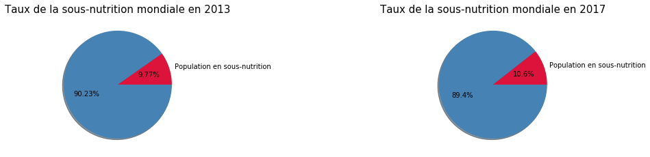

```python
undernourished3=undernourished.loc[undernourished["year"]==2013]
undernourished7=undernourished.loc[undernourished["year"]==2017]

ssn=pd.DataFrame({"2013": [undernourished3["undernourished"].sum(), POPULATION_2013],
                  "2017": [undernourished7["undernourished"].sum(), POPULATION_2017]},
                  index=["Population en sous-nutrition", ""])

plt.figure(figsize=(18, 8))
plt.figure(1)

plt.subplot(2, 2, 1)
ssn["2013"].plot(kind="pie", colors=["crimson", "steelblue"], autopct=lambda x: str(round(x, 2))+"%", shadow=True)
plt.title("Taux de la sous-nutrition mondiale en 2013", fontsize=15), plt.ylabel("")

plt.subplot(2, 2, 2)
ssn["2017"].plot(kind="pie", colors=["crimson", "steelblue"], autopct=lambda x: str(round(x, 2))+"%", shadow=True)
plt.title("Taux de la sous-nutrition mondiale en 2017", fontsize=15), plt.ylabel("") ; plt.show()
```

Ainsi, on observe que **9,77%** de la population mondiale est sous-alimentée en 2013 et **10,6%** en 2017.

### **Question 11:** *En ne prenant en compte que les céréales destinées à l'alimentation (humaine et animale), quelle proportion (en termes de poids) est destinée à l'alimentation animale?*

La table cer présente le bilan alimentaire pour éléments considérés comme des céréales par la FAO dans chaque pays pour les années 2012 à 2017.

```python
cer = pd.read_csv("data/projet_3/lustre/cereal.csv") ; cer
```

|  | country_code | country | year | element | item | value | unity |
| --- | --- | --- | --- | --- | --- | --- | --- |
| 0 | 2 | Afghanistan | 2012 | Production | Blé | 5050.0 | Milliers de tonnes |
| 1 | 2 | Afghanistan | 2012 | Importations - Quantité | Blé | 1334.0 | Milliers de tonnes |
| 2 | 2 | Afghanistan | 2012 | Variation de stock | Blé | -500.0 | Milliers de tonnes |
| 3 | 2 | Afghanistan | 2012 | Disponibilité intérieure | Blé | 5884.0 | Milliers de tonnes |
| 4 | 2 | Afghanistan | 2012 | Semences | Blé | 316.0 | Milliers de tonnes |
| ... | ... | ... | ... | ... | ... | ... | ... |
| 113890 | 25 | Îles Salomon | 2017 | Nourriture | Céréales, Autres | 0.0 | Milliers de tonnes |
| 113891 | 25 | Îles Salomon | 2017 | Disponibilité alimentaire en quantité (kg/pers... | Céréales, Autres | 0.0 | kg |
| 113892 | 25 | Îles Salomon | 2017 | Disponibilité alimentaire (Kcal/personne/jour) | Céréales, Autres | 0.0 | Kcal/personne/jour |
| 113893 | 25 | Îles Salomon | 2017 | Disponibilité de protéines en quantité (g/pers... | Céréales, Autres | 0.0 | g/personne/jour |
| 113894 | 25 | Îles Salomon | 2017 | Disponibilité de matière grasse en quantité (g... | Céréales, Autres | 0.0 | g/personne/jour |

113895 rows × 7 columns

Créons une colone "is_cereal" dans ba qui renvoie True si l'élément de la ligne en question est considéré comme une céréale par la FAO, False sinon, ainsi que la table "ba_cereal" qui nous renvoie ba localisée sur les produits considérés comme des céréales.

```python
ba["is_cereal"] = ba["item"].isin(cer.item)
ba_cereal = ba.loc[ba["is_cereal"]==True]
ba[["item", "is_cereal"]].drop_duplicates()
```

|  | item | is_cereal |
| --- | --- | --- |
| 90 | Blé | True |
| 91 | Orge | True |
| 92 | Maïs | True |
| 93 | Millet | True |
| 94 | Céréales, Autres | True |
| ... | ... | ... |
| 12555 | Animaux Aquatiques Autre | False |
| 12556 | Plantes Aquatiques | False |
| 12557 | Huiles de Poissons | False |
| 12558 | Huiles de Foie de Poisso | False |
| 2051 | Viande de Anim Aquatiq | False |

98 rows × 2 columns

Localisons les produits reconnus comme des céréales par la FAO (en 2013 et en 2017). On peut alors calculer le pourcentage de l'alimentation en céréales destinée aux animaux.

```python
ba3 = ba.loc[ba["year"]==2013]
ba7 = ba.loc[ba["year"]==2017]

ba3_cereal = ba3.loc[ba3["is_cereal"]==True]
ba7_cereal = ba7.loc[ba7["is_cereal"]==True]

animal_cereal_percentage_2013 = 100*ba3_cereal.feed.sum()/(ba3_cereal.feed.sum()+ba3_cereal.food.sum())
animal_cereal_percentage_2017 = 100*ba7_cereal.feed.sum()/(ba7_cereal.feed.sum()+ba7_cereal.food.sum())

print("2013:", animal_cereal_percentage_2013)
print("2017:", animal_cereal_percentage_2017)
```

```
2013: 45.91402568664604
2017: 43.760605996212306
```

### **Question 12:** *Sélectionnez parmi les données des bilans alimentaires les informations relatives aux pays dans lesquels la FAO recense des personnes en sous-nutrition. Repérez les 15 produits les plus exportés par ce groupe de pays. Parmi les données des bilans alimentaires au niveau mondial, sélectionnez les 200 plus grandes importations de ces produits (1 importation = une quantité d'un produit donné importée par un pays donné). Groupez ces importations par produit, afin d'avoir une table contenant 1 ligne pour chacun des 15 produits. Ensuite, calculez pour chaque produit les 2 quantités suivantes: le ratio entre la quantité destinés aux "Autres utilisations" (Other uses) et la disponibilité intérieure et le ratio entre la quantité destinée à la nourriture animale et la quantité destinée à la nourriture (animale + humaine). Donnez les 3 produits qui ont la plus grande valeur pour chacun des 2 ratios (vous aurez donc 6 produits à citer).*

Commençons par faire un petit merge entre ba et le DataFrame indiquant le nombre de personne en sous-alimentation par pays.

```python
bap = pd.merge(ba, undernourished) ; bap
```

|  | country_code | country | item_code | item | year | origin | feed | other_uses | food_supply_kcalcapitaday | domestic_supply_quantity_kgcapitayear | ... | food_supply_kgproteine | food_supply_kcalakg | proteine_percentage | domestic_supply_kcal | domestic_supply_kgproteine | feed_and_waste_kg | feed_and_waste_kcal | feed_and_waste_proteine | is_cereal | undernourished |
| --- | --- | --- | --- | --- | --- | --- | --- | --- | --- | --- | --- | --- | --- | --- | --- | --- | --- | --- | --- | --- | --- |
| 0 | 2 | Afghanistan | 2511 | Blé | 2012 | vegetal | 0.0 | NaN | 1378.0 | 161.27 | ... | 4.045284e+08 | 3118.727703 | 8.410154 | 1.835059e+13 | 4.948535e+08 | 5.568000e+09 | 1.736508e+13 | 4.682774e+08 | True | 7100000.0 |
| 1 | 2 | Afghanistan | 2513 | Orge | 2012 | vegetal | 367.0 | NaN | 23.0 | 2.61 | ... | 7.729149e+06 | 3210.011218 | 9.909165 | 1.665996e+12 | 5.142857e+07 | 4.970000e+08 | 1.595376e+12 | 4.924855e+07 | True | 7100000.0 |
| 2 | 2 | Afghanistan | 2514 | Maïs | 2012 | vegetal | 200.0 | NaN | 22.0 | 2.60 | ... | 6.313952e+06 | 3110.321429 | 8.199938 | 9.766409e+11 | 2.574781e+07 | 3.080000e+08 | 9.579790e+11 | 2.525581e+07 | True | 7100000.0 |
| 3 | 2 | Afghanistan | 2517 | Millet | 2012 | vegetal | 0.0 | NaN | 4.0 | 0.47 | ... | 9.797512e+05 | 3110.321429 | 6.998223 | 4.665482e+10 | 1.049733e+06 | 1.500000e+07 | 4.665482e+10 | 1.049733e+06 | True | 7100000.0 |
| 4 | 2 | Afghanistan | 2520 | Céréales, Autres | 2012 | vegetal | 0.0 | NaN | 0.0 | 0.00 | ... | 0.000000e+00 | NaN | NaN | NaN | NaN | 0.000000e+00 | NaN | NaN | True | 7100000.0 |
| ... | ... | ... | ... | ... | ... | ... | ... | ... | ... | ... | ... | ... | ... | ... | ... | ... | ... | ... | ... | ... | ... |
| 94820 | 25 | Îles Salomon | 2781 | Huiles de Poissons | 2017 | animal | 0.0 | 0.0 | 0.0 | 0.00 | ... | 0.000000e+00 | NaN | NaN | NaN | NaN | 0.000000e+00 | NaN | NaN | False | 57000.0 |
| 94821 | 25 | Îles Salomon | 2782 | Huiles de Foie de Poisso | 2017 | animal | 0.0 | 0.0 | 0.0 | 0.00 | ... | 0.000000e+00 | NaN | NaN | NaN | NaN | 0.000000e+00 | NaN | NaN | False | 57000.0 |
| 94822 | 25 | Îles Salomon | 2805 | Riz (Eq Blanchi) | 2017 | vegetal | 8.0 | 0.0 | 606.0 | 92.78 | ... | 2.460839e+06 | 2384.503180 | 4.170913 | 1.836067e+11 | 3.211603e+06 | 6.700000e+07 | 1.597617e+11 | 2.794512e+06 | True | 57000.0 |
| 94823 | 25 | Îles Salomon | 2848 | Lait - Excl Beurre | 2017 | animal | 0.0 | NaN | 19.0 | 5.78 | ... | 2.646562e+05 | 1102.734350 | 6.616406 | 4.410937e+09 | 2.646562e+05 | 4.000000e+06 | 4.410937e+09 | 2.646562e+05 | False | 57000.0 |
| 94824 | 25 | Îles Salomon | 2899 | Miscellanees | 2017 | vegetal | 0.0 | NaN | 8.0 | 7.34 | ... | 5.571710e+04 | 371.447360 | 1.114342 | 1.857237e+09 | 5.571710e+04 | 5.000000e+06 | 1.857237e+09 | 5.571710e+04 | False | 57000.0 |

94825 rows × 33 columns

Puis localisations les pays où la FAO recense des personnes en sous-nutrition.

```python
bap_undernourished = bap.loc[bap["undernourished"]>0]
np.array(bap_undernourished["country"].drop_duplicates())
```

```
array(['Afghanistan', 'Afrique du Sud', 'Albanie', 'Algérie', 'Angola',
       'Arabie saoudite', 'Argentine', 'Arménie', 'Australie',
       'Bangladesh', 'Barbade', 'Belize',
       'Bolivie (État plurinational de)', 'Botswana', 'Brunéi Darussalam',
       'Brésil', 'Bulgarie', 'Burkina Faso', 'Bénin', 'Cabo Verde',
       'Cambodge', 'Cameroun', 'Chili', 'Chine - RAS de Macao',
       'Chine, Taiwan Province de', 'Chine, continentale', 'Chypre',
       'Colombie', 'Congo', 'Costa Rica', 'Croatie', "Côte d'Ivoire",
       'Djibouti', 'Dominique', 'El Salvador', 'Estonie', 'Eswatini',
       'Fidji', 'Gabon', 'Gambie', 'Ghana', 'Guatemala', 'Guinée',
       'Guinée-Bissau', 'Guyana', 'Géorgie', 'Haïti', 'Honduras', 'Inde',
       'Indonésie', "Iran (République islamique d')", 'Iraq', 'Jamaïque',
       'Jordanie', 'Kenya', 'Kirghizistan', 'Kiribati', 'Koweït',
       'Lesotho', 'Liban', 'Libéria', 'Macédoine du Nord', 'Madagascar',
       'Malaisie', 'Malawi', 'Maldives', 'Mali', 'Maroc', 'Maurice',
       'Mauritanie', 'Mexique', 'Mongolie', 'Mozambique', 'Myanmar',
       'Namibie', 'Nicaragua', 'Niger', 'Nigéria', 'Népal', 'Oman',
       'Ouganda', 'Ouzbékistan', 'Pakistan', 'Panama', 'Paraguay',
       'Philippines', 'Polynésie française', 'Pérou', 'Rwanda',
       'République centrafricaine', 'République dominicaine',
       'République démocratique populaire lao',
       'République populaire démocratique de Corée',
       'République-Unie de Tanzanie', 'Saint-Vincent-et-les Grenadines',
       'Samoa', 'Sao Tomé-et-Principe', 'Serbie', 'Sierra Leone',
       'Slovaquie', 'Soudan', 'Sri Lanka', 'Suriname', 'Sénégal', 'Tchad',
       'Thaïlande', 'Timor-Leste', 'Togo', 'Trinité-et-Tobago', 'Tunisie',
       'Turkménistan', 'Ukraine', 'Vanuatu',
       'Venezuela (République bolivarienne du)', 'Viet Nam', 'Yémen',
       'Zambie', 'Zimbabwe', 'Égypte', 'Émirats arabes unis', 'Équateur',
       "États-Unis d'Amérique", 'Éthiopie', 'Îles Salomon'], dtype=object)
```

Localisons les données pour l'année 2013 puis pour l'année 2017 afin d'avoir les tables que nous utiliserons dans toute la suite de cette question.

```python
bap3_undernourished = bap_undernourished.loc[bap_undernourished["year"]==2013]
bap7_undernourished = bap_undernourished.loc[bap_undernourished["year"]==2017]
```

**2013:** Repérons les 15 produits les plus exportés par ces pays.

```python
export_2013=pd.DataFrame(bap3_undernourished.groupby("item").
                         sum()["exportation_quantity"]).sort_values("exportation_quantity", ascending=False).head(15)
export_2013
```

| item | exportation_quantity |
| --- | --- |
| Soja | 96386.0 |
| Maïs | 89472.0 |
| Blé | 79492.0 |
| Sucre Eq Brut | 57056.0 |
| Huile de Palme | 46546.0 |
| Riz (Eq Blanchi) | 37917.0 |
| Manioc | 35898.0 |
| Lait - Excl Beurre | 29688.0 |
| Légumes, Autres | 23776.0 |
| Oranges, Mandarines | 21563.0 |
| Bananes | 18680.0 |
| Fruits, Autres | 17437.0 |
| Poissons Pelagiques | 14872.0 |
| Orge | 13438.0 |
| Tomates | 10858.0 |

Localisons les données du bilan alimentaire pour ces 15 produits, puis sélectionnons les 200 plus grandes importations de ces produits.

```python
import_2013 = bap3_undernourished.loc[bap3_undernourished["item"].isin(export_2013.index)].sort_values(
    by= "importation_quantity", ascending=False).head(200)
import_2013[["country", "item", "exportation_quantity", "importation_quantity"]]
```

|  | country | item | exportation_quantity | importation_quantity |
| --- | --- | --- | --- | --- |
| 19316 | Chine, continentale | Soja | 250.0 | 63381.0 |
| 19303 | Chine, continentale | Manioc | 41.0 | 29046.0 |
| 3897 | Arabie saoudite | Orge | 0.0 | 10547.0 |
| 91563 | Égypte | Blé | 191.0 | 10331.0 |
| 37115 | Inde | Huile de Palme | 143.0 | 8568.0 |
| ... | ... | ... | ... | ... |
| 85580 | Tunisie | Soja | 0.0 | 467.0 |
| 62567 | Ouganda | Blé | 88.0 | 464.0 |
| 7815 | Bangladesh | Maïs | 0.0 | 463.0 |
| 3932 | Arabie saoudite | Huile de Palme | 20.0 | 460.0 |
| 54738 | Mexique | Orge | 108.0 | 458.0 |

200 rows × 4 columns

Repérons maintenant les quantités d'importation de ces mêmes produits, ainsi que les 2 ratios other_uses/domestic supply et nouriture animale sur nourriture humaine et animale.

```python
import_2013 = pd.DataFrame(import_2013.groupby("item")["importation_quantity", "other_uses", "domestic_supply",
                                                "feed", "food"].sum()).sort_values(by="importation_quantity", ascending=False)

import_2013["other_uses_on_domestic_supply"] = import_2013["other_uses"] / import_2013["domestic_supply"]
import_2013["feed_on_food"] = import_2013["feed"] / (import_2013["food"] + import_2013["feed"])
import_2013.drop(columns=["other_uses", "domestic_supply", "feed", "food"], inplace=True) ; import_2013
```

| item | importation_quantity | other_uses_on_domestic_supply | feed_on_food |
| --- | --- | --- | --- |
| Blé | 108221.0 | 0.027479 | 0.179829 |
| Soja | 77601.0 | 0.003677 | 0.664915 |
| Maïs | 60275.0 | 0.260794 | 0.868270 |
| Lait - Excl Beurre | 41932.0 | 0.033141 | 0.029377 |
| Sucre Eq Brut | 34360.0 | 0.043258 | 0.000000 |
| Manioc | 34154.0 | 0.318699 | 0.623545 |
| Huile de Palme | 27185.0 | 0.685842 | 0.000000 |
| Riz (Eq Blanchi) | 21421.0 | 0.048863 | 0.080303 |
| Orge | 19040.0 | 0.000239 | 0.949236 |
| Poissons Pelagiques | 12019.0 | 0.002332 | 0.648456 |
| Légumes, Autres | 8887.0 | 0.000025 | 0.005261 |
| Fruits, Autres | 7026.0 | 0.000000 | 0.000000 |
| Bananes | 5675.0 | 0.000000 | 0.000000 |
| Oranges, Mandarines | 2962.0 | 0.000122 | 0.000000 |
| Tomates | 1586.0 | 0.000000 | 0.000000 |

Enfin, localisons les 3 produits qui ont la plus grande valeur pour chacun de ces deux ratios et donnons ces 6 résultats dans un DataFrame.

```python
print("2013")
pd.DataFrame({c: [i for i in import_2013.sort_values(by=c, ascending=False).head(3).index]
             for c in ["other_uses_on_domestic_supply", "feed_on_food"]}, index=range(1, 4))
```

```
2013
```

|  | other_uses_on_domestic_supply | feed_on_food |
| --- | --- | --- |
| 1 | Huile de Palme | Orge |
| 2 | Manioc | Maïs |
| 3 | Maïs | Soja |

On réitère l'ensemble de ces dernières opérations afin d'afficher les résultats pour 2017.

```python
export_2017=pd.DataFrame(bap7_undernourished.groupby("item").
                         sum()["exportation_quantity"]).sort_values("exportation_quantity", ascending=False).head(15)

import_2017 = bap7_undernourished.loc[bap7_undernourished["item"].isin(export_2017.index)].sort_values(
    by= "importation_quantity", ascending=False).head(200)

import_2017 = pd.DataFrame(import_2017.groupby("item")["importation_quantity", "other_uses", "domestic_supply",
                                                "feed", "food"].sum()).sort_values(by="importation_quantity", ascending=False)

import_2017["other_uses_on_domestic_supply"] = import_2017["other_uses"] / import_2017["domestic_supply"]
import_2017["feed_on_food"] = import_2017["feed"] / (import_2017["food"] + import_2017["feed"])
import_2017.drop(columns=["other_uses", "domestic_supply", "feed", "food"], inplace=True)

print("2017")
pd.DataFrame({c: [i for i in import_2017.sort_values(by=c, ascending=False).head(3).index]
             for c in ["other_uses_on_domestic_supply", "feed_on_food"]}, index=range(1, 4))
```

```
2017
```

|  | other_uses_on_domestic_supply | feed_on_food |
| --- | --- | --- |
| 1 | Huile de Palme | Orge |
| 2 | Manioc | Poissons Pelagiques |
| 3 | Maïs | Maïs |

### **Question 13:** *Combien de tonnes de céréales pourraient être libérées si les USA diminuaient leur production de produits animaux de 10%?*

Localisons dans le bilan alimentaire le bilan en céréales aux Etats-Unis. Nous avons la quantité de nourriture pour animaux en milliers de tonnes, nous allons donc calculer 10% de cette quantité totale en multipliant cette quantité par 1000, puis en la divisant par 10, soit en la multipliant simplement par 100.

```python
usa = bap[(bap["country"] == "États-Unis d'Amérique") & (bap["is_cereal"]==True)]
free_cereals_2013 = 100*usa.loc[usa["year"]==2013].feed.sum()
free_cereals_2017 = 100*usa.loc[usa["year"]==2017].feed.sum()

print("2013:", free_cereals_2013)
print("2017:", free_cereals_2017)
```

```
2013: 14009600.0
2017: 14042400.0
```

On pourrait donc libérer 14009600 tonnes de céréales 2013 si les USA réduisaient leur production de produits animaux de 10%, et 14042400 tonnes en 2017.

### **Question 14:** *En Thaïlande, quelle proportion de manioc est exportée ? Quelle est la proportion de personnes en sous-nutrition?*

```python
thai = bap.loc[(bap["country"]=="Thaïlande") & (bap["item"]=="Manioc")]

thai3=thai.loc[thai["year"]==2013]
thai7=thai.loc[thai["year"]==2017]

manioc_exp_2013 = 100*float(thai3.exportation_quantity)/(
                            float(thai3.production)+
                            float(thai3.importation_quantity)+
                            float(thai3.stock_variation))

print("2013:", manioc_exp_2013)
```

```
2013: 80.1003875722727
```

Enfin, nous donnons le pourcentage de la population en sous-nutrition.

```python
thai_undernourrished_2013 = round(100*float(thai3.undernourished)/float(thai3.population), 2)
thai_undernourrished_2017 = round(100*float(thai7.undernourished)/float(thai7.population), 2)

print("La Thaïlande comptait %s" %thai_undernourrished_2013 + "% de sa population en sous-nutrition en 2013 et",
     str(thai_undernourrished_2017) + "% en 2017")
```

```
La Thaïlande comptait 8.36% de sa population en sous-nutrition en 2013 et 7.8% en 2017
```